# Chapter 3: Data Visualisation

# 3.1 Introduction

```r
library(tidyverse)
```

# 3.2 First steps

## 3.2.4 Exercises

1. Run `ggplot(data = mpg)` what do you see?

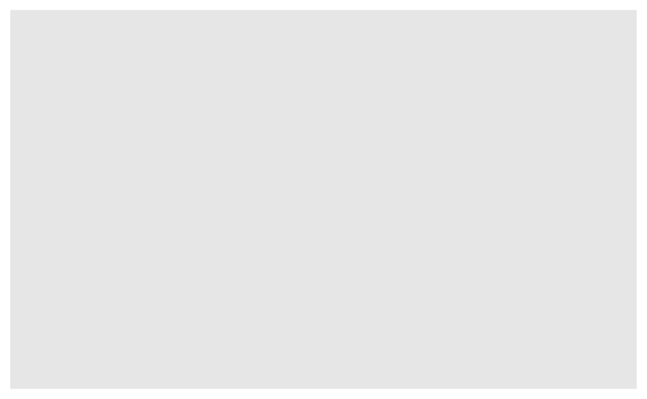

```r
ggplot(data = mpg)
```

**Nothing, because there haven’t been any geom layers placed on the graph.**

2. How many rows are in `mtcars`? How many columns?

```r
mtcars
```

|  | mpg | cyl | disp | hp | drat | wt | qsec | vs | am | gear | carb |
| --- | --- | --- | --- | --- | --- | --- | --- | --- | --- | --- | --- |
| Mazda RX4 | 21.0 | 6 | 160.0 | 110 | 3.90 | 2.620 | 16.46 | 0 | 1 | 4 | 4 |
| Mazda RX4 Wag | 21.0 | 6 | 160.0 | 110 | 3.90 | 2.875 | 17.02 | 0 | 1 | 4 | 4 |
| Datsun 710 | 22.8 | 4 | 108.0 | 93 | 3.85 | 2.320 | 18.61 | 1 | 1 | 4 | 1 |
| Hornet 4 Drive | 21.4 | 6 | 258.0 | 110 | 3.08 | 3.215 | 19.44 | 1 | 0 | 3 | 1 |
| Hornet Sportabout | 18.7 | 8 | 360.0 | 175 | 3.15 | 3.440 | 17.02 | 0 | 0 | 3 | 2 |
| Valiant | 18.1 | 6 | 225.0 | 105 | 2.76 | 3.460 | 20.22 | 1 | 0 | 3 | 1 |
| Duster 360 | 14.3 | 8 | 360.0 | 245 | 3.21 | 3.570 | 15.84 | 0 | 0 | 3 | 4 |
| Merc 240D | 24.4 | 4 | 146.7 | 62 | 3.69 | 3.190 | 20.00 | 1 | 0 | 4 | 2 |
| Merc 230 | 22.8 | 4 | 140.8 | 95 | 3.92 | 3.150 | 22.90 | 1 | 0 | 4 | 2 |
| Merc 280 | 19.2 | 6 | 167.6 | 123 | 3.92 | 3.440 | 18.30 | 1 | 0 | 4 | 4 |

[output cut: 22 more lines]

**32 rows and 11 columns.**

3. What does the `drv` variable describe? Read the help for `?mpg` to find out.

```r
?mpg
```

**f = front-wheel drive, r = rear wheel drive, 4 = 4wd**

4. Make a scatterplot of `hwy` vs `cyl`.

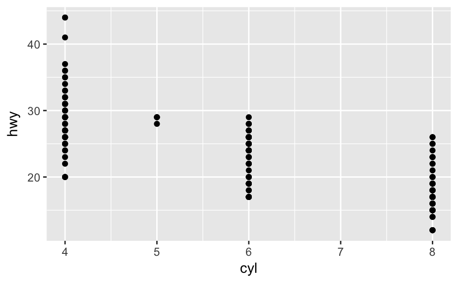

```r
ggplot(data = mpg) +
  geom_point(mapping = aes(x = cyl, y = hwy))
```

5. What happens if you make a scatterplot of `class` vs `drv`. Why is the plot not useful?

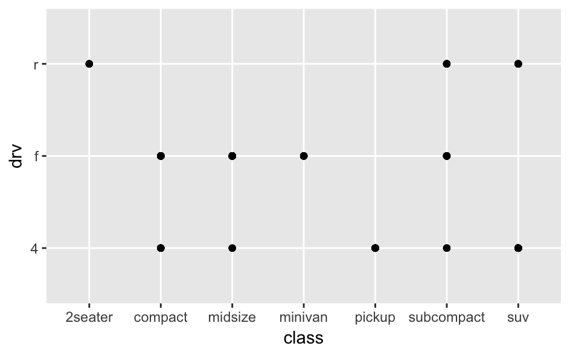

```r
ggplot(data = mpg) +
  geom_point(mapping = aes(x = class, y = drv))
```

**These are categorical (nominal) variables so the order along each axis is meaningless.**

# 3.3 Aesthetic mappings

## 3.3.1 Exercises

1. What’s gone wrong with this code? Why are the points not blue?

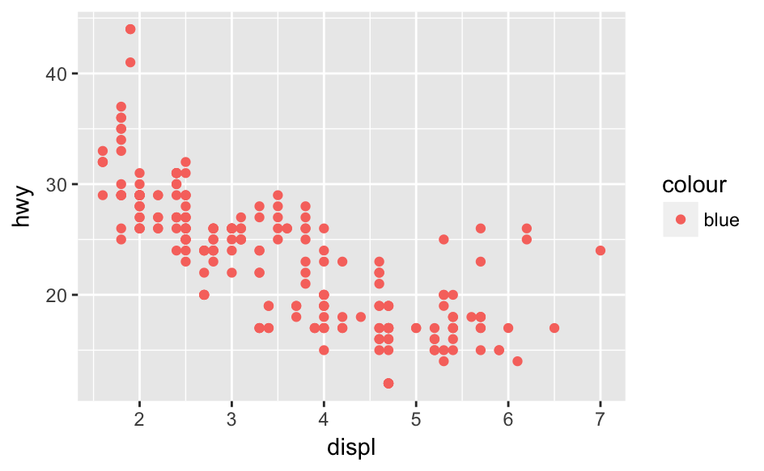

```r
ggplot(data = mpg) +
  geom_point(mapping = aes(x = displ, y = hwy, color = "blue"))
```

**Manually setting colour needs to happen outside of the `aes` function call.**

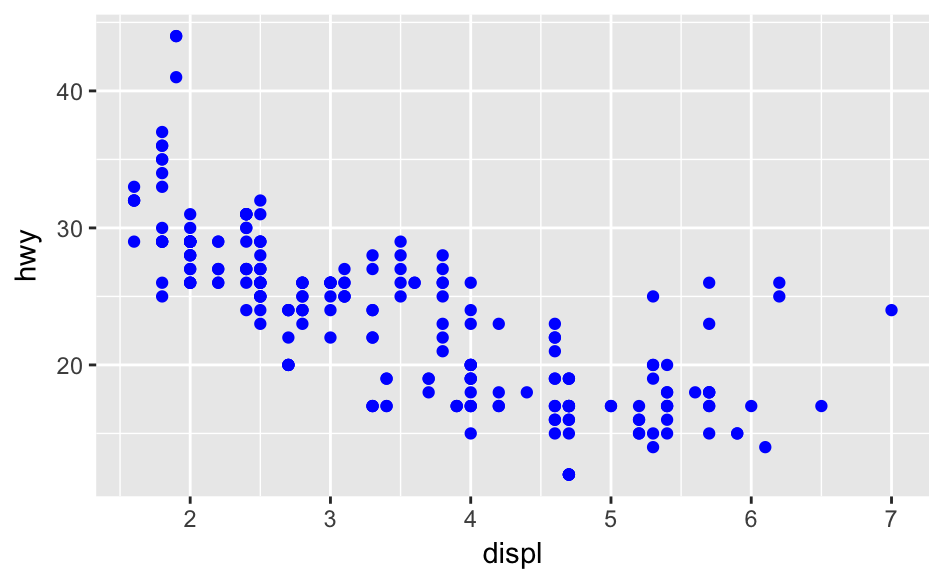

```r
ggplot(data = mpg) +
  geom_point(mapping = aes(x = displ, y = hwy), colour = "blue")
```

2. Which variables in `mpg` are categorical? Which variables are continuous? (Hint: type `?mpg` to read the documentation for the dataset). How can you see this information when you run `mpg`?

```r
?mpg
```

**Categorical variables are `manufacturer`, `model`, `trans`, `drv`, `fl` and `class`. Continuous variables are `displ`, `year`, `cyl`, `cty` and `hwy`.**

```r
mpg
```

| manufacturer | model | displ | year | cyl | trans | drv | cty | hwy | fl | class |
| --- | --- | --- | --- | --- | --- | --- | --- | --- | --- | --- |
| audi | a4 | 1.8 | 1999 | 4 | auto(l5) | f | 18 | 29 | p | compact |
| audi | a4 | 1.8 | 1999 | 4 | manual(m5) | f | 21 | 29 | p | compact |
| audi | a4 | 2.0 | 2008 | 4 | manual(m6) | f | 20 | 31 | p | compact |
| audi | a4 | 2.0 | 2008 | 4 | auto(av) | f | 21 | 30 | p | compact |
| audi | a4 | 2.8 | 1999 | 6 | auto(l5) | f | 16 | 26 | p | compact |
| audi | a4 | 2.8 | 1999 | 6 | manual(m5) | f | 18 | 26 | p | compact |
| audi | a4 | 3.1 | 2008 | 6 | auto(av) | f | 18 | 27 | p | compact |
| audi | a4 quattro | 1.8 | 1999 | 4 | manual(m5) | 4 | 18 | 26 | p | compact |
| audi | a4 quattro | 1.8 | 1999 | 4 | auto(l5) | 4 | 16 | 25 | p | compact |
| audi | a4 quattro | 2.0 | 2008 | 4 | manual(m6) | 4 | 20 | 28 | p | compact |

[output cut: 224 more lines]

**Each variable’s data type indicates whether it is categorical (chr) or continuous (int).**

3. Map a continuous variable to `color`, `size`, and `shape`. How do these aesthetics behave differently for categorical vs. continuous variables?

```r
ggplot(data = mpg) +
  geom_point(mapping = aes(x = displ, y = hwy, colour = year, size = cty, shape = cyl))
```

```
Error: A continuous variable can not be mapped to shape
```

**Shape won’t allow a continuous variable to be mapped onto it.**

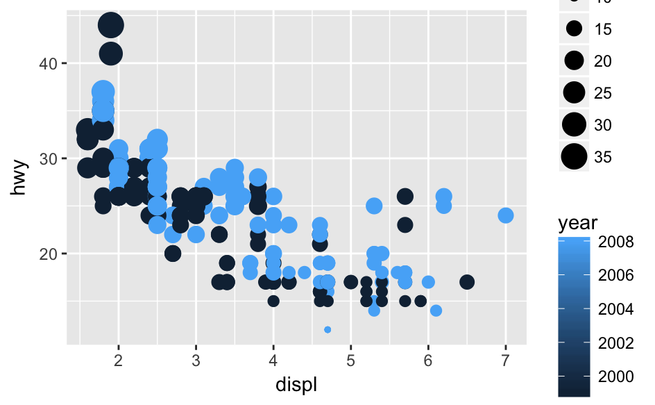

```r
ggplot(data = mpg) +
  geom_point(mapping = aes(x = displ, y = hwy, colour = year, size = cty))
```

**Colour uses a gradient/shades to reflect the values of the variable, and size scales the items based on value.**

4. What happens if you map the same variable to multiple aesthetics?

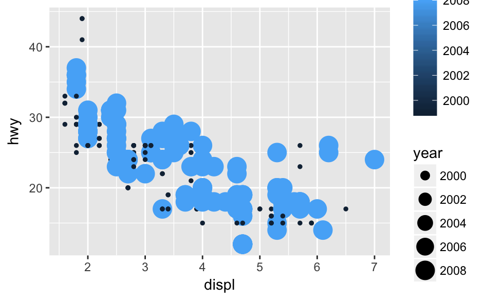

```r
ggplot(data = mpg) +
  geom_point(mapping = aes(x = displ, y = hwy, colour = year, size = year))
```

**Both mappings are performed. Note above that all the points of a given colour are the same size, because both size and colour reflectvalues on the same underlying variable.**

5. What does the `stroke` aesthetic do? What shapes does it work with? (Hint: use `?geom_point`)

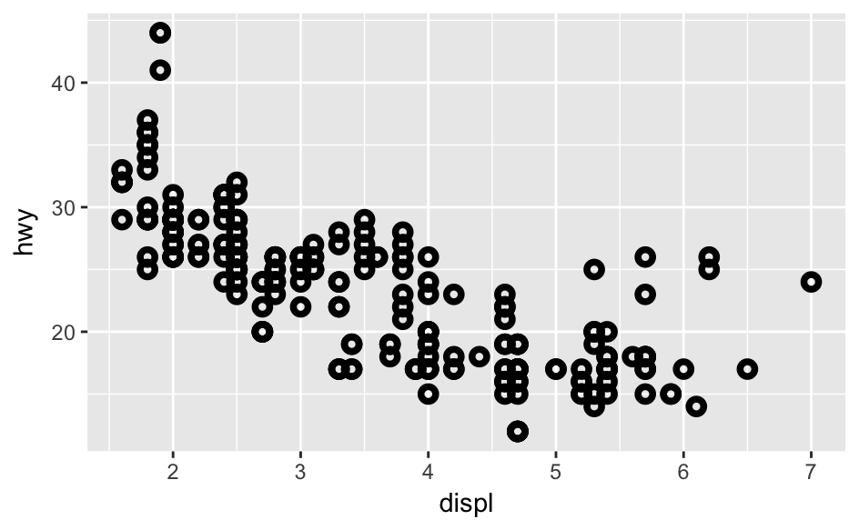

```r
?geom_point
ggplot(data = mpg) +
  geom_point(mapping = aes(x = displ, y = hwy), shape = 21, stroke = 2)
```

**It sets the colour width of the border for shapes that have a border.**

6. What happens if you map an aesthetic to something other than a variable name, like `aes(colour = displ < 5)`?

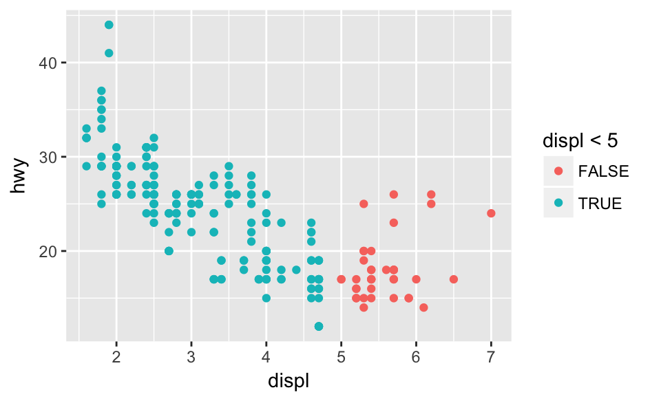

```r
ggplot(data = mpg) +
  geom_point(mapping = aes(x = displ, y = hwy, colour = displ < 5))
```

**It evaluates the expression and applies an aesthetic based on the value (in this case, the boolean check on whether `displ` is less than 5.)**

# 3.5 Facets

## 3.5.1 Exercises

1. What happens if you facet on a continuous variable?

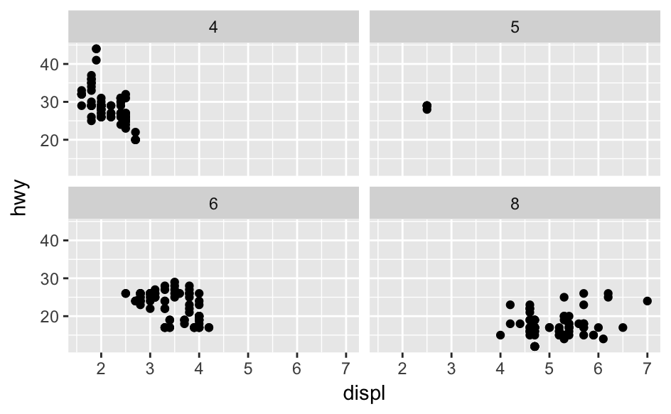

```r
ggplot(data = mpg) +
  geom_point(mapping = aes(x = displ, y = hwy)) +
  facet_wrap(~ cyl, nrow = 2)
```

**It creates a subplot for each value of the variable and presents them in order of value.**

2. What do the empty cells in plot with `facet_grid(drv ~ cyl)` mean? How do they relate to this plot?

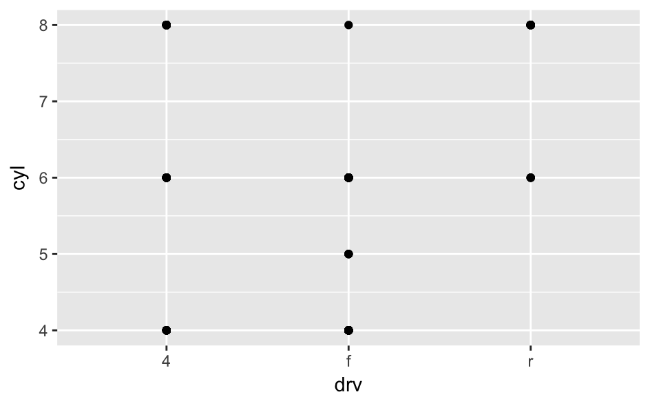

```r
ggplot(data = mpg) +
  geom_point(mapping = aes(x = drv, y = cyl))
```

**There are some combinations of the values of `drv` and `cyl` with no matching observations in the data, which means the plots will be empty.**

3. What plots does the following code make? What does `.` do?

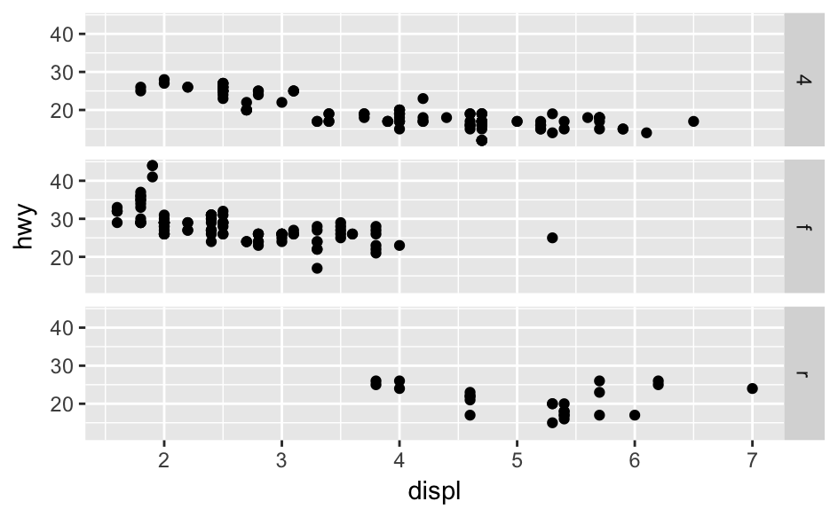

```r
ggplot(data = mpg) +
  geom_point(mapping = aes(x = displ, y = hwy)) +
  facet_grid(drv ~ .)
```

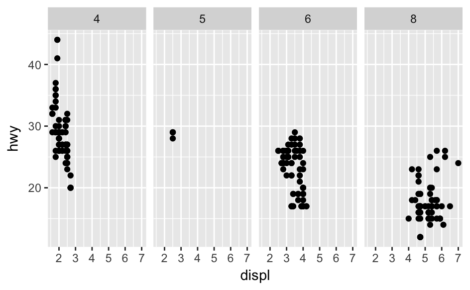

```r
ggplot(data = mpg) +
  geom_point(mapping = aes(x = displ, y = hwy)) +
  facet_grid(. ~ cyl)
```

**`.` indicates that the grid should only have a single row or column.**

4. Take the first faceted plot in this section:

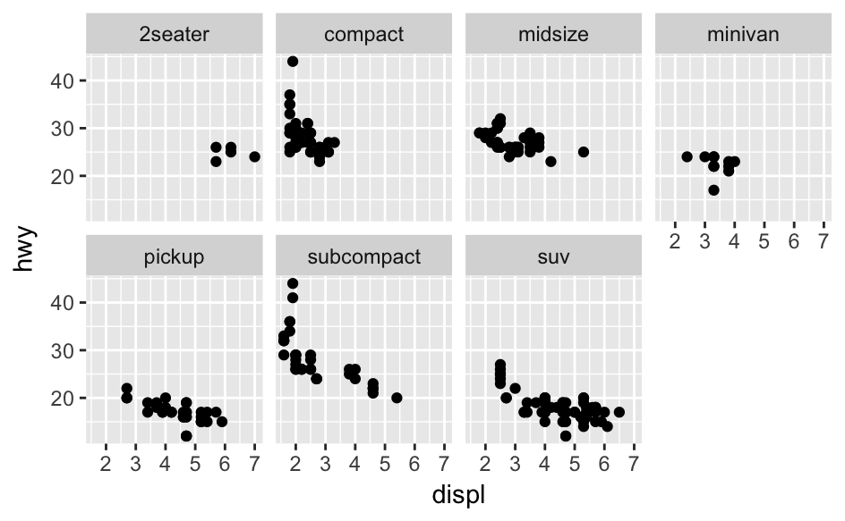

```r
ggplot(data = mpg) +
  geom_point(mapping = aes(x = displ, y = hwy)) +
  facet_wrap(~ class, nrow = 2)
```

What are the advantages to using faceting instead of the colour aesthetic? What are the disadvantages? How might the balance change if you had a larger dataset?

**Facets separate out the subsets of the data whereas a colour aesthetic differentiates subsets but leaves them intermingled in a single plot. The main advantages that come from this separation are that you can more easily observe the patterns in each subset of data, and comparisons across subsets can be made quite clearly. The disadvantage is that the overall patterns in the full set of data may be more difficult to examine.**

**If you had a larger dataset then facets may become even more useful and a colour aesthetic may become more difficult to examine because there would often be a great deal of overlap in the data points.**

5. Read `?facet_wrap`. What does `nrow` do? What does `ncol` do? What other options control the layout of the individual panels? Why doesn’t `facet_grid()` have `nrow` and `ncol` variables?

```r
?facet_wrap
```

**`nrow` sets the number of rows and `ncol` sets the number of columns. These variables aren’t available in `facet_grid` because when using it, the number of rows is determined by the number of values on the variable being used for the row dimension, and the number of columns is determined by the number of values on the variable being used for the column dimension.**

6. When using `facet_grid(`) you should usually put the variable with more unique levels in the columns. Why?

**To minimise the number of rows and height of the overall plot, and to allow comparison of subplots across the full width of the rows.**

# 3.6 Geometric objects

## 3.6.1 Exercises

1. What geom would you use to draw a line chart? A boxplot? A histogram? An area chart?

**Line chart: `geom_line`** **Boxplot: `geom_boxplot`** **Histogram: `geom_histogram`** **Area chart: `geom_area`**

2. Run this code in your head and predict what the output will look like. Then, run the code in R and check your predictions.

**Scatter plot plus lines of best fit (without confidence range) for highway fuel efficiency vs engine displacement, with separately coloured points and lines for each drivetrain type.**

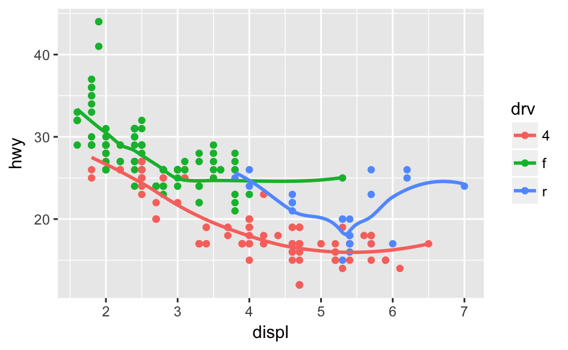

```r
ggplot(data = mpg, mapping = aes(x = displ, y = hwy, color = drv)) +
  geom_point() +
  geom_smooth(se = FALSE)
```

3. What does `show.legend = FALSE` do? What happens if you remove it? Why do you think I used it earlier in the chapter?

**Removes the legend from displaying with a plot.**

4. What does the `se` argument to `geom_smooth()` do?

**Sets whether to display standard error range around the line.**

5. Will these two graphs look different? Why/why not?

**No, because they each have the same aesthetics set for the two geom layers being placed on the plot – the only difference is that in the first plot this is done by setting global aesthetics vs duplication on each geom layer in the second plot.**

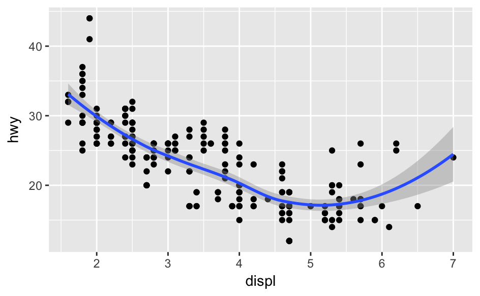

```r
ggplot(data = mpg, mapping = aes(x = displ, y = hwy)) +
  geom_point() +
  geom_smooth()
```

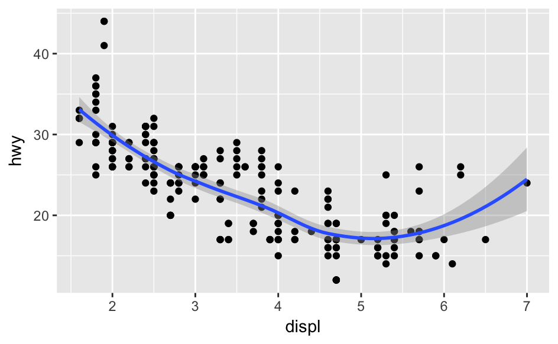

```r
ggplot() +
  geom_point(data = mpg, mapping = aes(x = displ, y = hwy)) +
  geom_smooth(data = mpg, mapping = aes(x = displ, y = hwy))
```

6. Recreate the R code necessary to generate the following graphs.

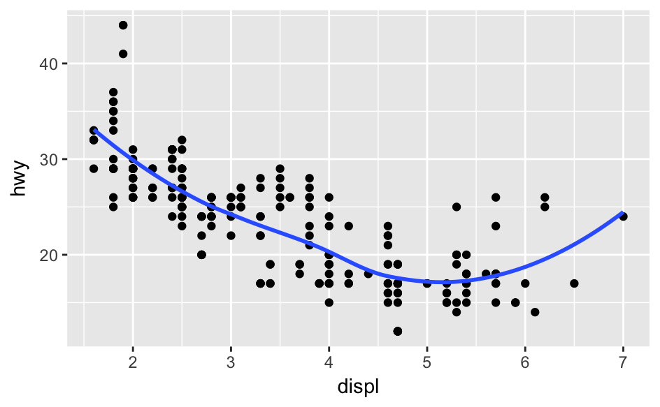

```r
ggplot(data = mpg, mapping = aes(x = displ, y = hwy)) +
  geom_point() +
  geom_smooth(se = FALSE)
```

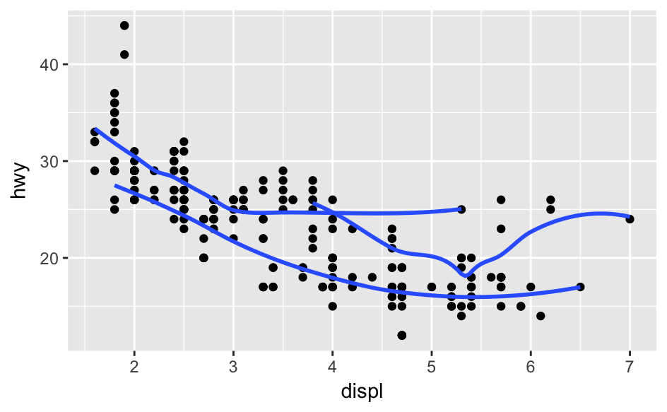

```r
ggplot(data = mpg, mapping = aes(x = displ, y = hwy)) +
  geom_point() +
  geom_smooth(mapping = aes(group = drv), se = FALSE)
```

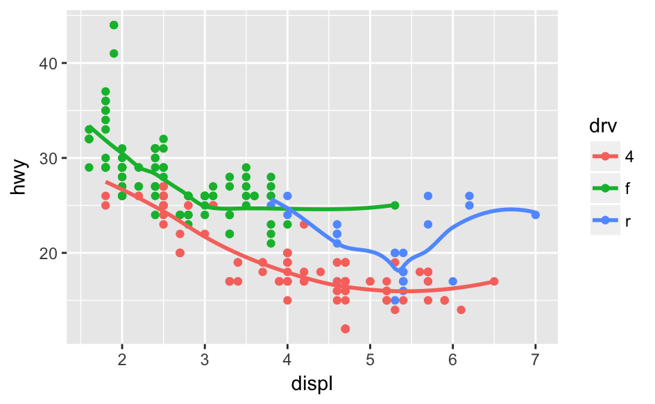

```r
ggplot(data = mpg, mapping = aes(x = displ, y = hwy, colour = drv)) +
  geom_point() +
  geom_smooth(se = FALSE)
```

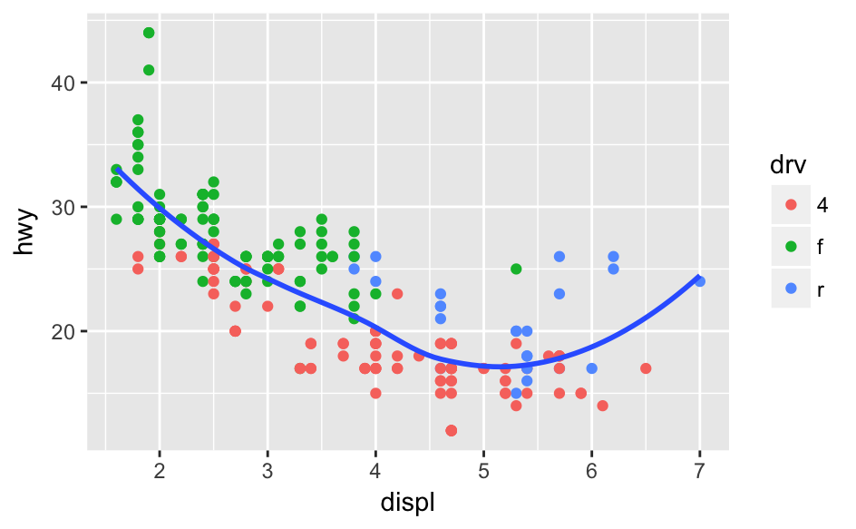

```r
ggplot(data = mpg, mapping = aes(x = displ, y = hwy)) +
  geom_point(mapping = aes(colour = drv)) +
  geom_smooth(se = FALSE)
```

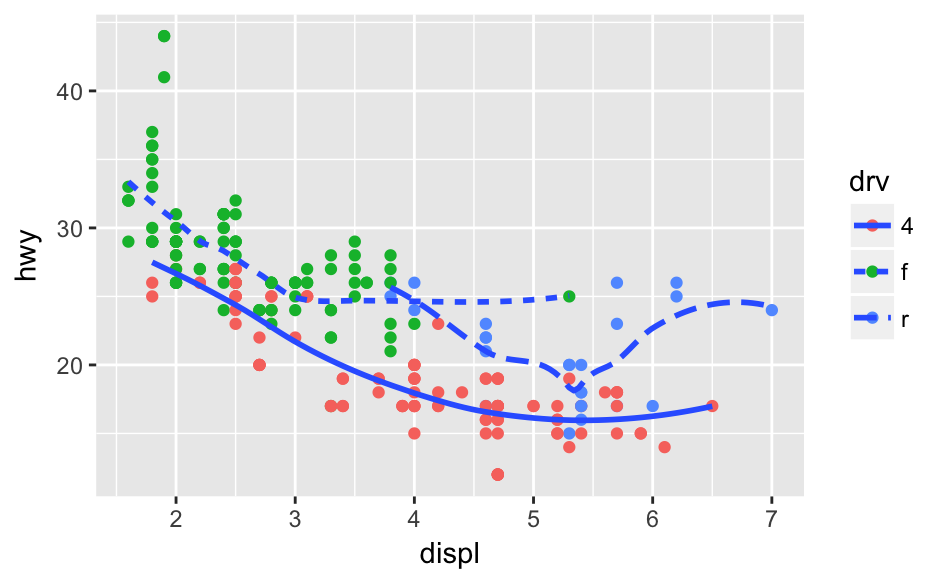

```r
ggplot(data = mpg, mapping = aes(x = displ, y = hwy)) +
  geom_point(mapping = aes(colour = drv)) +
  geom_smooth(mapping = aes(linetype = drv), se = FALSE)
```

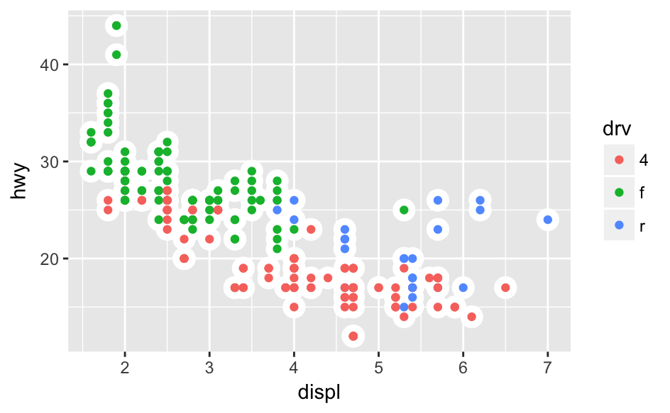

```r
ggplot(data = mpg, mapping = aes(x = displ, y = hwy)) +
  geom_point(colour = "white", size = 5) +
  geom_point(mapping = aes(colour = drv))
```

# 3.7 Statistical transformations

## 3.7.1 Exercises

1. What is the default geom associated with `stat_summary()`? How could you rewrite the previous plot to use that geom function instead of the stat function?

**The default geom is `pointrange`.**

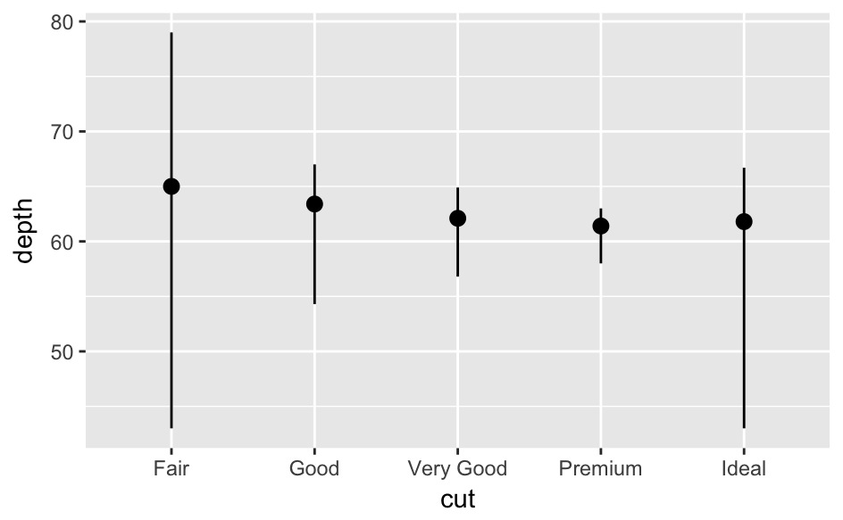

```r
ggplot(data = diamonds) +
  geom_pointrange(mapping = aes(x = cut, y = depth),
                  stat = "summary",
                  fun.ymin = min,
                  fun.ymax = max,
                  fun.y = median)
```

2. What does `geom_col()` do? How is it different to `geom_bar()`?

```r
?geom_col
```

**`geom_col` uses identity rather than count as the stat, meaning that instead of counting up the frequency it uses the values in the data to determine the height of the bars.**

3. Most geoms and stats come in pairs that are almost always used in concert. Read through the documentation and make a list of all the pairs. What do they have in common?

```r
?geom_abline
?geom_area
?geom_bar
?geom_bin2d
?geom_blank
?geom_boxplot
?geom_col
?geom_contour
?geom_count
?geom_crossbar
?geom_curve
?geom_density
```

4. What variables does `stat_smooth()` compute? What parameters control its behaviour?

```r
?stat_smooth
```

**`stat_smooth` computes conditional means along the range of x values that can then be plotted as a smoothed line. Its behaviour is controlled by `method` which sets the smoothing function to use, `formula` which determines the formula to use, `se` which determines whether surrounding confidence intervals will be computed and displayed.**

5. In our proportion bar chart, we need to set `group = 1`. Why? In other words what is the problem with these two graphs?

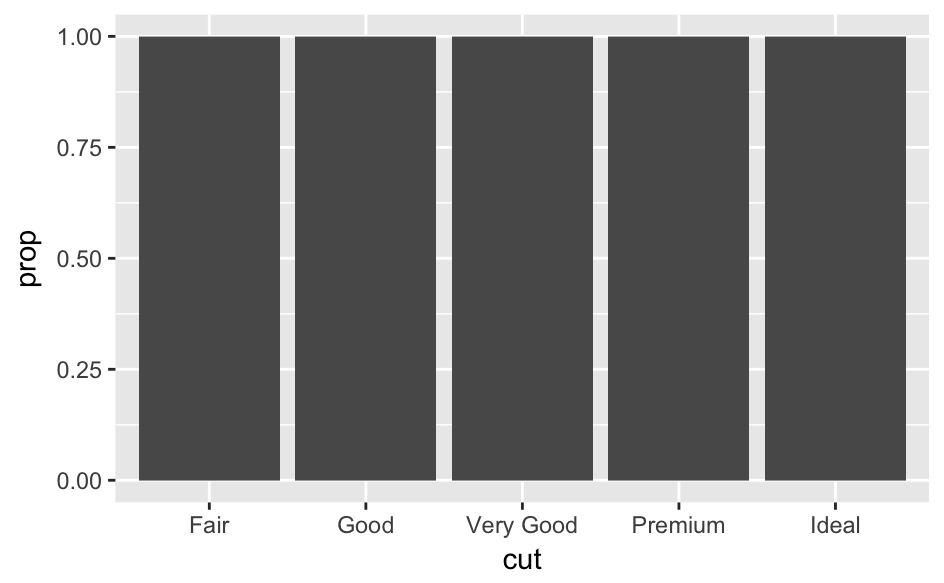

```r
ggplot(data = diamonds) +
  geom_bar(mapping = aes(x = cut, y = ..prop..))
```

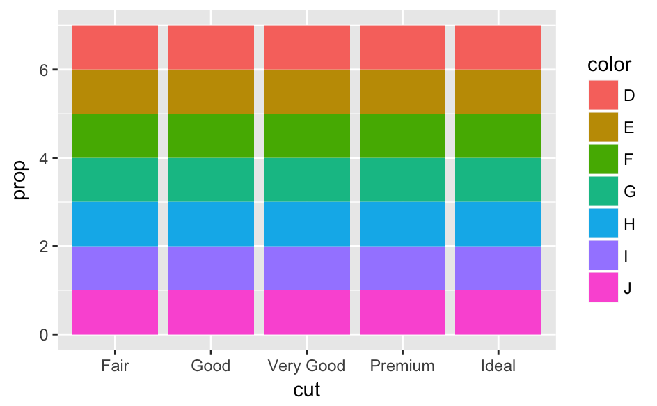

```r
ggplot(data = diamonds) +
  geom_bar(mapping = aes(x = cut, fill = color, y = ..prop..))
```

**Prop calculates the groupwise proportion so we need a variable that ensures the proportions are calculated relative to the total number of cases across all cut categories.**

# 3.8 Position adjustments

## 3.8.1 Exercises

1. What is the problem with this plot? How could you improve it?

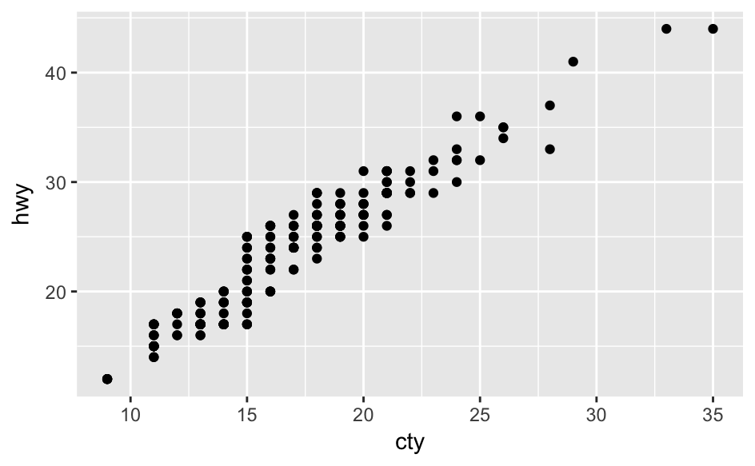

```r
ggplot(data = mpg, mapping = aes(x = cty, y = hwy)) +
  geom_point()
```

**There is overplotting so it’s unclear when there are multiple data points clustered together. This can be addressed by adding jitter.**

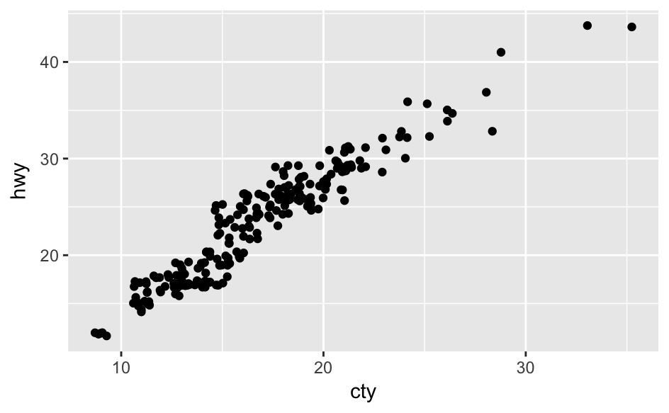

```r
ggplot(data = mpg, mapping = aes(x = cty, y = hwy)) +
  geom_point(position = "jitter")
```

2. What parameters to `geom_jitter()` control the amount of jittering?

```r
?geom_jitter
```

**`width` and `height` control the amount of horizontal and vertical jitter, respectively.**

3. Compare and contrast `geom_jitter()` with `geom_count()`.

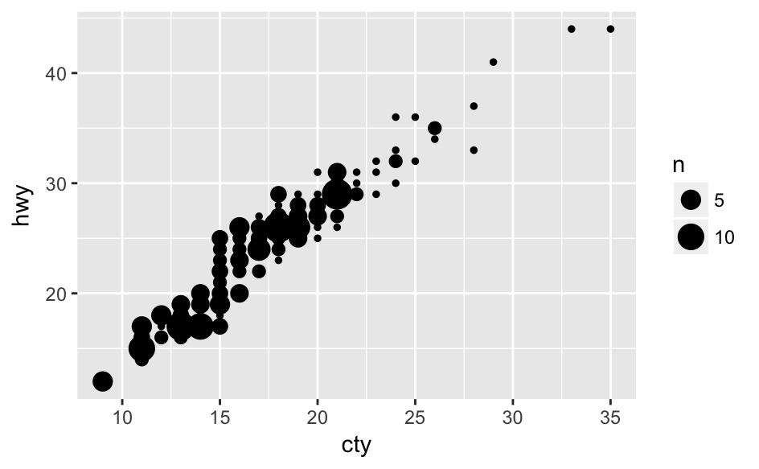

```r
ggplot(data = mpg, mapping = aes(x = cty, y = hwy)) +
  geom_count()
```

4. What’s the default position adjustment for `geom_boxplot()`? Create a visualisation of the mpg dataset that demonstrates it.

**The default position is dodge, which places overlapping objects directly beside one another.**

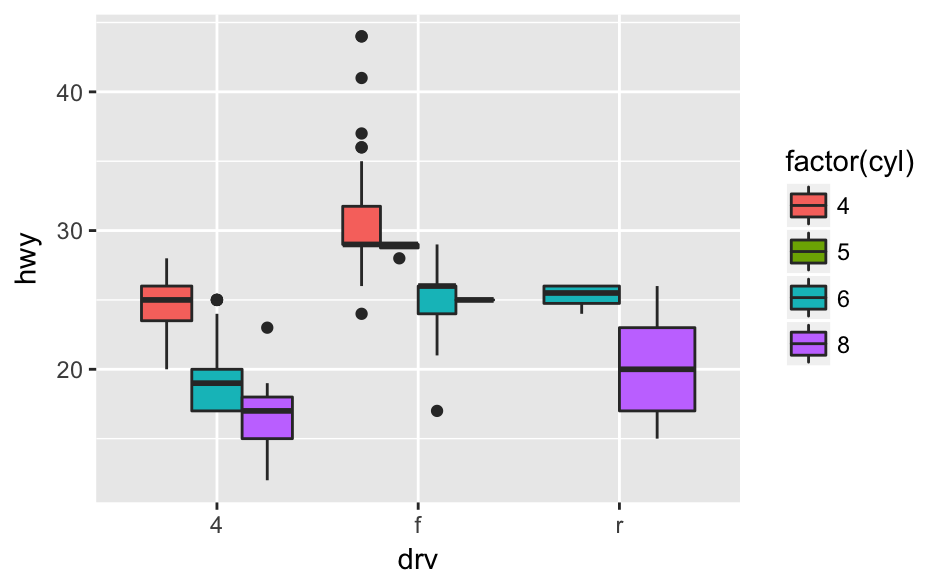

```r
ggplot(data = mpg) +
  geom_boxplot(mapping = aes(x = drv, y = hwy, fill = factor(cyl)))
```